# w241_final_project

```r
library(stringr)
library(dplyr)
library(stargazer)
library(lmtest)
library(sandwich)
library(ggplot2)
library(magrittr)
library(lmtest)
library(ri2)
library(data.table)
```

## Loading Data

```r
d = read.csv('~/Desktop/PrelimRESULTS.csv')
#g1 = read.csv('~/Desktop/group1.csv')
#g2_sms = read.csv('~/Desktop/group2_SMS.csv')
#g2_no_sms = read.csv('~/Desktop/group2_NoSMS.csv')
s_prior = read.csv('~/Desktop/scripts_prior.csv')
s_during = read.csv('~/Desktop/scripts_during.csv')
```

## Combining the PrelimRESULTS table with the two scripts table using left join.

```r
# clean the final data file
df = d %>%
  transmute(id = UniqueID,
            treatment = ifelse(TREATMENT == '', '', ifelse(str_detect(TREATMENT,'CONTROL'), 0, 1)),
            group = ifelse(TREATMENT == '', '', ifelse(str_detect(TREATMENT,'GROUP 1'), 'No Phone', ifelse(str_detect(TREATMENT,'NO SMS'), 'No SMS', 'SMS'))),
            active_in_exp = ifelse(is.na(ACTIVE_IN._EXPERIMENT), 0, 1),
            active_3m = X3MONTH_ACTIVE,
            voucher = ifelse(VOUCHER == '', 0, 1),
            drug_count = Drug.Count,
            nov05_fail = ifelse(is.na(Nov05_FAIL), 0, 1),
            nov13_fail = ifelse(is.na(Nov13_FAIL), 0, 1),
            nov23_fail = ifelse(is.na(Nov23_FAIL), 0, 1),
            unsub = ifelse(Unsubscribe_Request == '', 0, 1),
            msg_fail = ifelse(is.na(Other_msg_fail), 0, 1),
            nursing_home = ifelse(is.na(Nursing_HOME), 0, 1),
            male = ifelse(is.na(MALE), 0, 1),
            reminder_type = Reminder.Type,
            address_group = Address.GROUP,
            carer_group = ifelse(is.na(CARER.GROUP), 0, 1),
            cell_phone = HAS_CELL_PHONE,
            email = HAS_EMAIL,
            cell_dup = ifelse(is.na(CELL_DUP_GP), 0, 1),
            name_dup = ifelse(is.na(NAME_DUP_GP), 0, 1)
            ) %>%
  filter(treatment != '') %>%
  filter(!duplicated(id)) # removing duplicated row, because some users converted reminder type half way through the experiment

s_p = s_prior %>%
  transmute(
    id = UNIQUE.ID,
    date = DATE,
    total_meds = Medications.ordered,
    self_meds = Ordered.for.self,
    other_meds = ORDERED.FOR.OTHER) %>%
  filter(as.Date(s_prior$DATE,'%d/%m/%Y') >= as.Date('5/8/2019','%d/%m/%Y')) %>% # filter for prior three month only
  group_by(id) %>%
  summarise(
    total_meds_3m = sum(total_meds),
    self_meds_3m = sum(self_meds),
    other_meds_3m = sum(other_meds)
  )

s_d = s_during %>%
  transmute(
    id = UNIQUE.ID,
    date = DATE,
    total_meds = Medications.ordered,
    self_meds = Ordered.for.self,
    other_meds = ORDERED.FOR.OTHER) %>%
  group_by(id) %>%
  summarise(
    total_meds_in_exp = sum(total_meds),
    self_meds_in_exp = sum(self_meds),
    other_meds_in_exp = sum(other_meds)
  )

df = df %>%
  left_join(.,s_p) %>%
  left_join(.,s_d) %>% data.table()
```

## Hypothesis 0: treatment effect, y = active login, x = treatment

### Random Inference: active login in exp ~ treatment, without correcting for clustered standard error

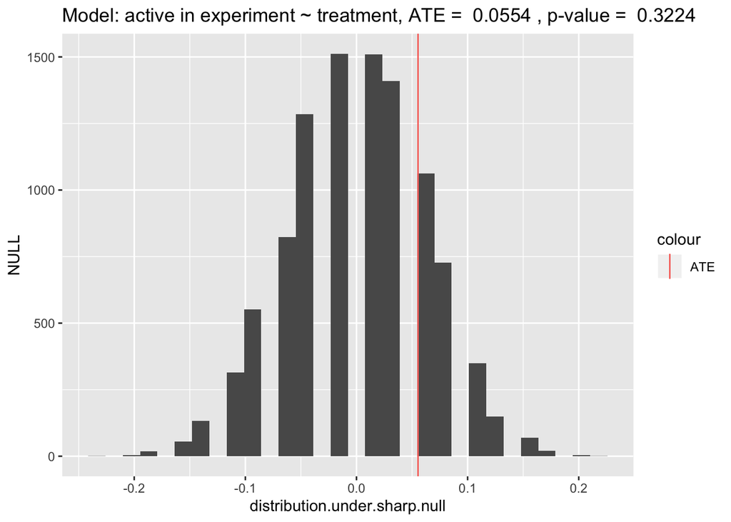

```r
# Define potential outcomes for control and treatment, under the sharp null hypothesis, these two vectors should be exactly the same

# Assign treatment and control potential outcomes
po.control = as.integer(df$active_in_exp)
po.treatment = po.control

# Randomly assign units into control and treatment group
randomize = function() {sample(c(rep(0,sum(df$treatment == 0)),rep(1,sum(df$treatment == 1))))}
t = randomize()

# Calculate the outcome according to control/treatment assignment
outcomes = po.treatment * t + po.control*(1-t)

# Estimate the Average Treatment Effect
est.ate = function(outcome,success){mean(outcome[success==1]) - mean(outcome[success==0])}
#est.ate(outcomes, randomize())

# Run simulation for 10,000 times
distribution.under.sharp.null <- replicate(10000, est.ate(outcomes, randomize()))

ATE = mean(as.numeric(df[df$treatment == 1]$active_in_exp)) - mean(as.numeric(df[df$treatment == 0]$active_in_exp))
p_value_two_tailed <- sum(abs(distribution.under.sharp.null) > ATE)/length(distribution.under.sharp.null)

qplot(distribution.under.sharp.null) +
 geom_vline(aes(xintercept = ATE,color = 'ATE')) +
  ggtitle(paste('Model: active in experiment ~ treatment, ATE = ', round(ATE,4), ', p-value = ', p_value_two_tailed))
```

```r
table(df$group, df$active_in_exp)
```

```
##
##             0  1
##   No Phone 32  2
##   No SMS   55 17
##   SMS      61 15
```

```r
lm0 = df[,lm(active_in_exp ~ treatment)] # base model
lm0$vcovCL1 = vcovCL(lm0, cluster = df[, c("carer_group", "address_group")])
#coeftest(lm0, vcov. = lm0$vcovCL1)

lm3 = df[,lm(active_in_exp ~ group)] # base model
lm3$vcovCL1 = vcovCL(lm3, cluster = df[, c("carer_group", "address_group")])
#coeftest(lm3, vcov. = lm3$vcovCL1)

lm1 = df[,lm(active_in_exp ~ group + treatment)] # base model + group
lm1$vcovCL1 = vcovCL(lm1, cluster = df[, c("carer_group", "address_group")])
#coeftest(lm1, vcov. = lm1$vcovCL1)

lm2 = df[,lm(active_in_exp ~ group + treatment + active_3m )] # base model + group + active_3m
lm2$vcovCL1 = vcovCL(lm2, cluster = df[, c("carer_group", "address_group")])
#coeftest(lm2, vcov. = lm2$vcovCL1)

stargazer(lm0, lm3, lm1, lm2,
          se = list(sqrt(diag(lm0$vcovCL1)),
                    sqrt(diag(lm3$vcovCL1)),
                    sqrt(diag(lm1$vcovCL1)),
                    sqrt(diag(lm2$vcovCL1))),
          type = 'text', header = FALSE,
          omit.stat = c('F', 'ser')
)
```

```
##
## ================================================
##                      Dependent variable:
##              -----------------------------------
##                         active_in_exp
##                (1)      (2)      (3)      (4)
## ------------------------------------------------
## treatment1    0.055             0.041    0.031
##              (0.060)           (0.061)  (0.033)
##
## active_3m                               0.679***
##                                         (0.121)
##
## groupNo SMS           0.177*** 0.171*** 0.053***
##                       (0.034)  (0.023)  (0.016)
##
## groupSMS              0.139*** 0.134***  0.016
##                       (0.008)  (0.016)  (0.033)
##
## Constant     0.152***  0.059    0.037   -0.018**
##              (0.020)  (0.048)           (0.009)
##
## ------------------------------------------------
## Observations   182      182      182      182
## R2            0.005    0.027    0.029    0.554
## Adjusted R2   -0.001   0.016    0.013    0.544
## ================================================
## Note:                *p<0.1; **p<0.05; ***p<0.01
```

- ATE is the same between RI and t-test, however, t-test uses clustered standard error.
- Treatment effect is not significant.
- Seems like which group the user is assigned to is more important
- Whether the user is active during the test period is highly correlated with whether he/she was active in the app three months before the experiment.
- Without explicitly specifying active_3m, being in either the No SMS and SMS is significant in predictinve active during experiment.
- Once active_3m is added, being in the SMS group is no longer significant. Is this a sign of covariate imbalance?

## Hypothesis 1: differential treatment effect by group, y = active login, x = treatment

```r
lm1 = df[group == 'No Phone', lm(active_in_exp ~ treatment)] # base model
lm1$vcovCL1 = vcovCL(lm1, cluster = df[group == 'No Phone', c("carer_group", "address_group")])
#coeftest(lm1, vcov. = lm1$vcovCL1)

lm2 = df[group == 'No Phone',lm(active_in_exp ~ treatment + active_3m)] # add active history
lm2$vcovCL1 = vcovCL(lm2, cluster = df[group == 'No Phone', c("carer_group", "address_group")])
#coeftest(lm2, vcov. = lm2$vcovCL1)

lm3 = df[group == 'No SMS', lm(active_in_exp ~ treatment)] # base model
lm3$vcovCL1 = vcovCL(lm3, cluster = df[group == 'No SMS', c("carer_group", "address_group")])
#coeftest(lm3, vcov. = lm3$vcovCL1)

lm4 = df[group == 'No SMS', lm(active_in_exp ~ treatment + active_3m)] # add active history
lm4$vcovCL1 = vcovCL(lm4, cluster = df[group == 'No SMS', c("carer_group", "address_group")])
#coeftest(lm4, vcov. = lm4$vcovCL1)

lm5 = df[group == 'SMS', lm(active_in_exp ~ treatment)] # base model
lm5$vcovCL1 = vcovCL(lm5, cluster = df[group == 'SMS', c("carer_group", "address_group")])
#coeftest(lm5, vcov. = lm5$vcovCL1)

lm6 = df[group == 'SMS', lm(active_in_exp ~ treatment + active_3m)] # add active history
lm6$vcovCL1 = vcovCL(lm6, cluster = df[group == 'SMS', c("carer_group", "address_group")])
#coeftest(lm6, vcov. = lm6$vcovCL1)

stargazer(lm1, lm3, lm5,
         se=list(sqrt(diag(lm1$vcovCL1)),
                 sqrt(diag(lm3$vcovCL1)),
                 sqrt(diag(lm5$vcovCL1))),
         type = 'text',header=FALSE,
         column.labels = c('No Phone','No SMS', 'SMS'))
```

```
##
## ============================================================================
##                                       Dependent variable:
##                     --------------------------------------------------------
##                                          active_in_exp
##                          No Phone            No SMS              SMS
##                            (1)                (2)                (3)
## ----------------------------------------------------------------------------
## treatment1                0.111              0.028              0.019
##                          (0.085)            (0.031)            (0.073)
##
## Constant                  0.000             0.217***           0.185***
##                                             (0.050)            (0.008)
##
## ----------------------------------------------------------------------------
## Observations                34                 72                 76
## R2                        0.056              0.001              0.001
## Adjusted R2               0.026              -0.013             -0.013
## Residual Std. Error  0.236 (df = 32)    0.431 (df = 70)    0.403 (df = 74)
## F Statistic         1.882 (df = 1; 32) 0.064 (df = 1; 70) 0.038 (df = 1; 74)
## ============================================================================
## Note:                                            *p<0.1; **p<0.05; ***p<0.01
```

- No evidence of differential treatment effect, as in treatment effect in all three groups are insignificant.

```r
stargazer(lm2, lm4, lm6,
         se=list(sqrt(diag(lm2$vcovCL1)),
                 sqrt(diag(lm4$vcovCL1)),
                 sqrt(diag(lm6$vcovCL1))),
         type = 'text',header=FALSE,
         column.labels = c('No Phone','No SMS', 'SMS'),
          omit.stat = c('F', 'ser')
         )
```

```
##
## ==========================================
##                   Dependent variable:
##              -----------------------------
##                      active_in_exp
##               No Phone   No SMS     SMS
##                 (1)        (2)      (3)
## ------------------------------------------
## treatment1    0.079***    0.024    0.015
##               (0.013)             (0.064)
##
## active_3m     0.655***  0.752***  0.614***
##               (0.215)    (0.141)  (0.086)
##
## Constant     -0.041***  0.021***   0.026
##               (0.009)    (0.005)  (0.051)
##
## ------------------------------------------
## Observations     34        72        76
## R2             0.674      0.609    0.462
## Adjusted R2    0.653      0.598    0.447
## ==========================================
## Note:          *p<0.1; **p<0.05; ***p<0.01
```

- Why did the SE for No SMS treatment group disappear??? it’s because of the clustered SE, but why?

## Hypothesis 2: reminder effect on voucher uptake, y = voucher, x = group

### Random Inference: voucher ~ reminder, without correcting for clustered standard error

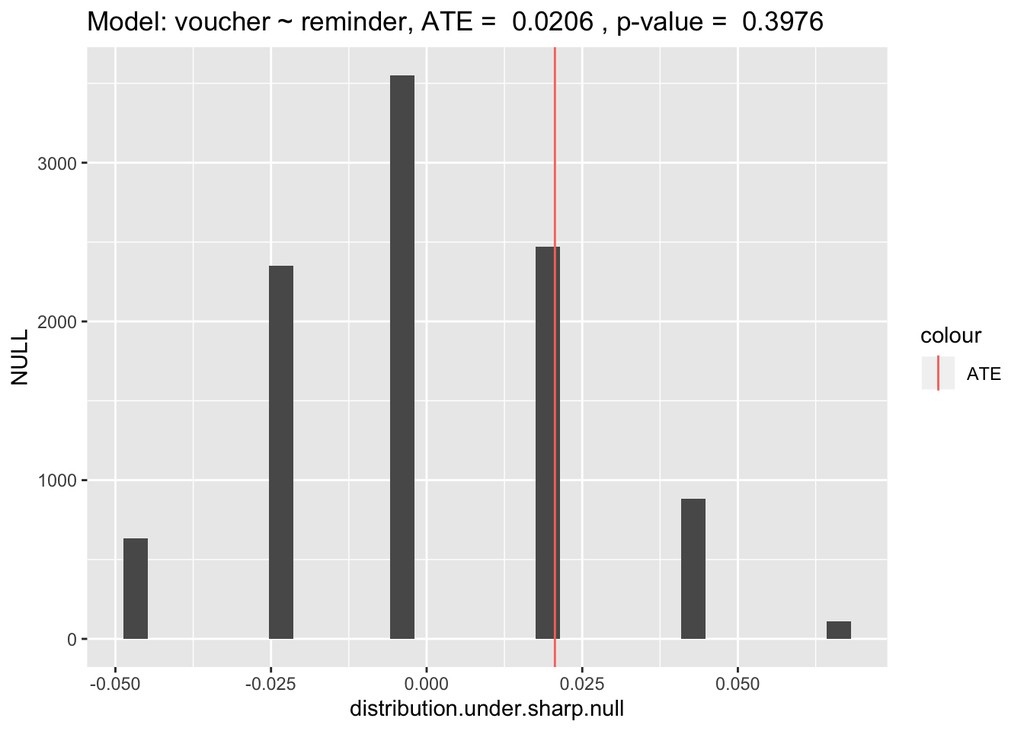

```r
# Define potential outcomes for control and treatment, under the sharp null hypothesis, these two vectors should be exactly the same

df$reminder = ifelse(df$group == 'SMS', 1, 0)

# Assign treatment and control potential outcomes
po.control = as.integer(df$voucher)
po.treatment = po.control

# Randomly assign units into control and treatment group
randomize = function() {sample(c(rep(0,sum(df$reminder == 0)),rep(1,sum(df$reminder == 1))))}
t = randomize()

# Calculate the outcome according to control/treatment assignment
outcomes = po.treatment * t + po.control*(1-t)

# Estimate the Average Treatment Effect
est.ate = function(outcome,success){mean(outcome[success==1]) - mean(outcome[success==0])}
#est.ate(outcomes, randomize())

# Run simulation for 10,000 times
distribution.under.sharp.null <- replicate(10000, est.ate(outcomes, randomize()))

ATE = mean(as.numeric(df[df$reminder == 1]$voucher)) - mean(as.numeric(df[df$reminder == 0]$voucher))
p_value_two_tailed <- sum(abs(distribution.under.sharp.null) > ATE)/length(distribution.under.sharp.null)

qplot(distribution.under.sharp.null) +
 geom_vline(aes(xintercept = ATE,color = 'ATE')) +
 ggtitle(paste('Model: voucher ~ reminder, ATE = ', round(ATE,4), ', p-value = ', p_value_two_tailed))
```

```r
table(df$group, df$voucher)
```

```
##
##             0  1
##   No Phone 33  1
##   No SMS   71  1
##   SMS      73  3
```

```r
lm1 = df[, lm(voucher ~ group - 1)] # base model
lm1$vcovCL1 = vcovCL(lm1, cluster = df[, c("carer_group", "address_group")])
#coeftest(lm1, vcov. = lm1$vcovCL1)

lm2 = df[, lm(voucher ~ group - 1)]
lm2$vcovHC_ <- vcovHC(lm2)
#coeftest(lm2, vcov. = lm2$vcovHC_)

stargazer(lm1, lm2,
          se = list(sqrt(diag(lm1$vcovCL1)),
                    sqrt(diag(lm2$vcovHC_))),
          type = 'text', header = FALSE,
         column.labels = c('Clustered SE','Robust SE'),
          omit.stat = c('F', 'ser')
          )
```

```
##
## ==========================================
##                   Dependent variable:
##               ----------------------------
##                         voucher
##                Clustered SE    Robust SE
##                     (1)           (2)
## ------------------------------------------
## groupNo Phone    0.029***        0.029
##                   (0.004)       (0.030)
##
## groupNo SMS      0.014***        0.014
##                   (0.004)       (0.014)
##
## groupSMS           0.039         0.039*
##                   (0.039)       (0.023)
##
## ------------------------------------------
## Observations        182           182
## R2                 0.032         0.032
## Adjusted R2        0.016         0.016
## ==========================================
## Note:          *p<0.1; **p<0.05; ***p<0.01
```

- reminder = 1 is equivalent to being in the SMS group, reminder = 0 means the user is either in the No Phone or No SMS group.
- Using the clustered SE, the result becomes counterintuitive…
- clustered SE really shrinks the CI for No Phone and No SMS groups.

## Hypothesis 3: treatment effect on scripts ordered, y = scripts ordered, x = treatment

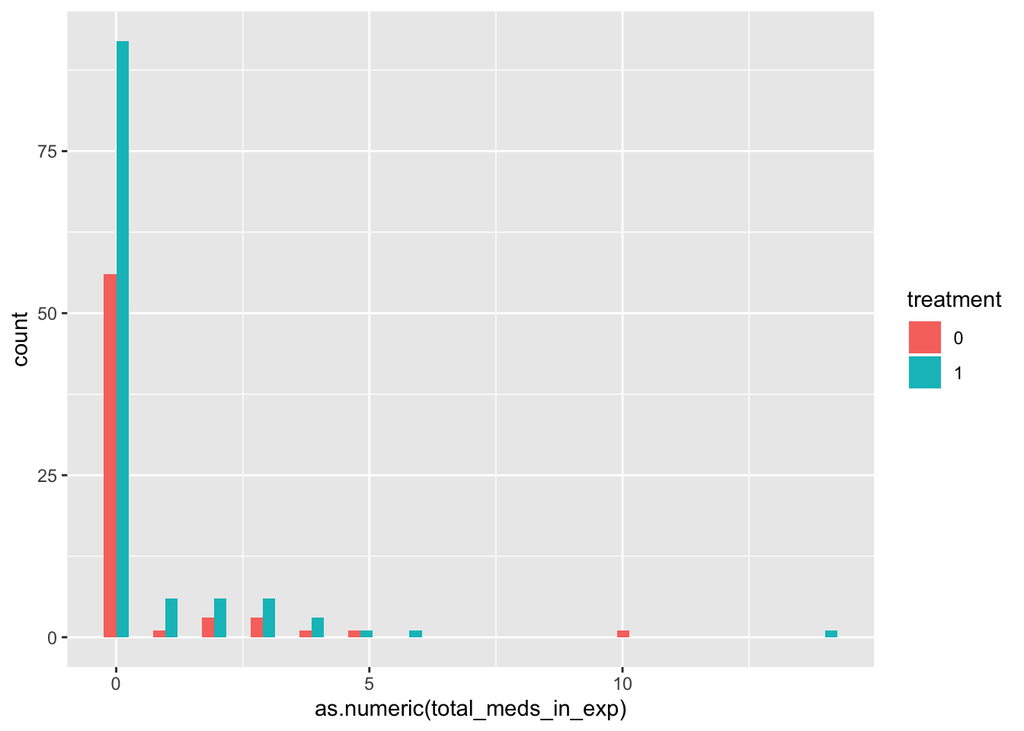

```r
df$total_meds_in_exp = as.integer(ifelse(is.na(df$total_meds_in_exp),0,df$total_meds_in_exp)) # need to fill the NAs
ggplot(data=df, aes(x = as.numeric(total_meds_in_exp), fill = treatment)) +
  geom_histogram(position="dodge")
```

- Highly skeweed distribution, normality assumption probably won’t hold given the sample size

```r
table(df$treatment, df$total_meds_in_exp)
```

```
##
##      0  1  2  3  4  5  6 10 14
##   0 56  1  3  3  1  1  0  1  0
##   1 92  6  6  6  3  1  1  0  1
```

```r
lm0 = df[, lm(total_meds_in_exp ~ treatment)] # base model
lm0$vcovCL1 = vcovCL(lm0, cluster = df[, c("carer_group", "address_group")])
#coeftest(lm0, vcov. = lm0$vcovCL1)

lm1 = df[, lm(total_meds_in_exp ~ treatment + total_meds_3m)] # base model + scripts 3m
lm1$vcovCL1 = vcovCL(lm1, cluster = df[, c("carer_group", "address_group")])
#coeftest(lm1, vcov. = lm1$vcovCL1)

lm2 = df[, lm(total_meds_in_exp ~ treatment + group + total_meds_3m)] # base model + group
lm2$vcovCL1 = vcovCL(lm2, cluster = df[, c("carer_group", "address_group")])
#coeftest(lm2, vcov. = lm2$vcovCL1)

lm4 = df[, lm(total_meds_in_exp ~ treatment + voucher + total_meds_3m)] # base model + voucher
lm4$vcovCL1 = vcovCL(lm4, cluster = df[, c("carer_group", "address_group")])
#coeftest(lm4, vcov. = lm4$vcovCL1)

lm5 = df[, lm(total_meds_in_exp ~ treatment + group + total_meds_3m + voucher )] # base model + group + scripts 3m + voucher
lm5$vcovCL1 = vcovCL(lm5, cluster = df[, c("carer_group", "address_group")])
#coeftest(lm5, vcov. = lm5$vcovCL1)

stargazer(lm0, lm1, lm2, lm4, lm5,
          se = list(sqrt(diag(lm0$vcovCL1)),
                    sqrt(diag(lm1$vcovCL1)),
                    sqrt(diag(lm2$vcovCL1)),
                    sqrt(diag(lm4$vcovCL1)),
                    sqrt(diag(lm5$vcovCL1))),
          type = 'text', header = FALSE,
          omit.stat = c('F', 'ser')
          )
```

```
##
## ==========================================================
##                           Dependent variable:
##               --------------------------------------------
##                            total_meds_in_exp
##                 (1)      (2)      (3)      (4)      (5)
## ----------------------------------------------------------
## treatment1     0.099    0.331    0.290    0.159    -0.010
##               (0.329)  (0.829)  (0.716)  (0.892)  (0.740)
##
## groupNo SMS                      1.586            2.439***
##                                 (1.520)           (0.883)
##
## groupSMS                         0.288            0.861***
##                                 (1.060)           (0.250)
##
## voucher                                  1.490*** 2.555***
##                                          (0.417)  (0.124)
##
## total_meds_3m          0.263*** 0.273*** 0.260*** 0.273***
##                        (0.011)  (0.037)  (0.006)  (0.023)
##
## Constant      0.530*** 0.600***  -0.287  0.615*** -0.941*
##               (0.109)  (0.113)  (1.102)  (0.192)  (0.518)
##
## ----------------------------------------------------------
## Observations    182       40       40       40       40
## R2             0.001    0.241    0.300    0.260    0.350
## Adjusted R2    -0.005   0.200    0.220    0.199    0.254
## ==========================================================
## Note:                          *p<0.1; **p<0.05; ***p<0.01
```

- Being in the treatment group is not predictive of total meds ordered during the experiment
- Power user effect: total meds ordered in the past 3 months is highly predictive of total meds ordered during the experiment
- Having redeemed the voucher produces positive impact on total meds ordered
- WOW is that last model the winner? having No Phone means significant negative impact on meds ordered through the app (denoted by the negative constant term). Redeeming the voucher, having SMS, and having No SMS, all show significant positive impact. feels too good to be true…

### Random Inference: total meds ordered in exp ~ treatment, without correcting for clustered standard error

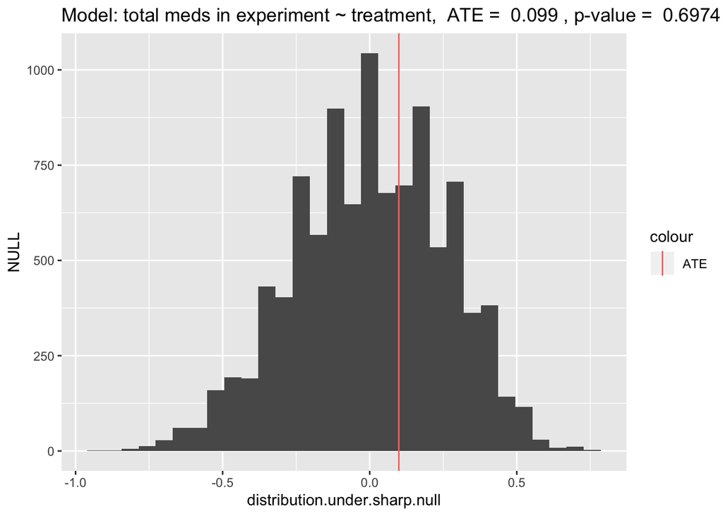

```r
# Define potential outcomes for control and treatment, under the sharp null hypothesis, these two vectors should be exactly the same
df = na.fill(df,0) %>% data.table()

# Assign treatment and control potential outcomes
po.control = as.integer(df$total_meds_in_exp)
po.treatment = po.control

# Randomly assign units into control and treatment group
randomize = function() {sample(c(rep(0,sum(df$treatment == 0)),rep(1,sum(df$treatment == 1))))}
t = randomize()

# Calculate the outcome according to control/treatment assignment
outcomes = po.treatment * t + po.control*(1-t)

# Estimate the Average Treatment Effect
est.ate = function(outcome,success){mean(outcome[success==1]) - mean(outcome[success==0])}
#est.ate(outcomes, randomize())

# Run simulation for 10,000 times
distribution.under.sharp.null <- replicate(10000, est.ate(outcomes, randomize()))

ATE = mean(as.numeric(df[df$treatment == 1]$total_meds_in_exp)) - mean(as.numeric(df[df$treatment == 0]$total_meds_in_exp))
p_value_two_tailed <- sum(abs(distribution.under.sharp.null) > ATE)/length(distribution.under.sharp.null)

qplot(distribution.under.sharp.null) +
 geom_vline(aes(xintercept = ATE,color = 'ATE')) +
  ggtitle(paste('Model: total meds in experiment ~ treatment, ','ATE = ', round(ATE,4), ', p-value = ', p_value_two_tailed))
```

- ATE is the same between RI and t-test, however, t-test uses clustered standard error.